# Análisis de variables categóricas, clasificación y optimización con redes neuronales - préstamos en instituciones bancarias

### Presentación de resultados

```python
import pandas as pd

cv_results = pd.DataFrame(gs2["all_results"])
cv_results.head(3)
```

|  | l1 | l2 | dr | scores_folds | accuracy_promedio |
| --- | --- | --- | --- | --- | --- |
| 0 | 16 | 16 | 0.0 | [0.7093023255813954, 0.7093023255813954, 0.744... | 0.720930 |
| 1 | 16 | 16 | 0.2 | [0.7093023255813954, 0.7209302325581395, 0.697... | 0.709302 |
| 2 | 16 | 64 | 0.0 | [0.6976744186046512, 0.6744186046511628, 0.732... | 0.701550 |

Entrena una red neuronal para clasificación binaria probando distintas combinaciones de neuronas y dropout, aplicando preprocesamiento a las variables numéricas y validación cruzada de 3 folds. Calcula el accuracy promedio de cada combinación, identifica la mejor configuración (l1=64, l2=64, dr=0) y muestra los resultados junto con el tiempo total de ejecución.

```python
import pandas as pd
import numpy as np

# Crear DataFrame a partir de gs2
cv_results = pd.DataFrame(gs2["all_results"])

# Añadir columnas 'mean_test_score' y 'std_test_score' para simular GridSearchCV
cv_results["mean_test_score"] = cv_results["accuracy_promedio"]
cv_results["std_test_score"] = cv_results["scores_folds"].apply(np.std)

# Renombrar columnas de hiperparámetros para que coincidan con el formato 'param_modelNN__...'
cv_results = cv_results.rename(columns={
    "l1": "param_modelNN__l1",
    "l2": "param_modelNN__l2",
    "dr": "param_modelNN__dr"
})

# Seleccionar y ordenar
cv_results = cv_results.sort_values("mean_test_score", ascending=False)
cv_results = cv_results[["mean_test_score", "std_test_score",
                         "param_modelNN__l1",
                         "param_modelNN__l2",
                         "param_modelNN__dr"]]

cv_results.head(3)
```

|  | mean_test_score | std_test_score | param_modelNN__l1 | param_modelNN__l2 | param_modelNN__dr |
| --- | --- | --- | --- | --- | --- |
| 6 | 0.786822 | 0.014503 | 64 | 64 | 0.0 |
| 7 | 0.767442 | 0.025119 | 64 | 64 | 0.2 |
| 3 | 0.732558 | 0.025119 | 16 | 64 | 0.2 |

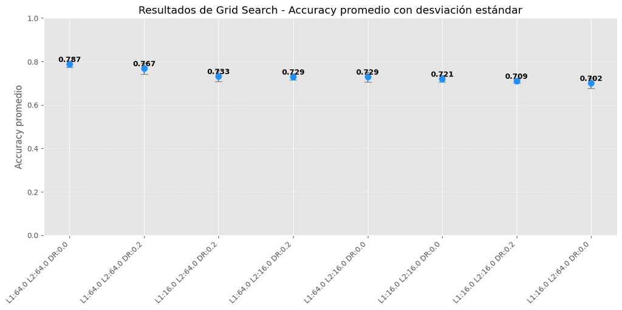

```python
import matplotlib.pyplot as plt
import numpy as np

# ---- Preparar etiquetas y valores ----
labels = [f"L1:{row['param_modelNN__l1']} L2:{row['param_modelNN__l2']} DR:{row['param_modelNN__dr']}"
          for idx, row in cv_results.iterrows()]
means = cv_results["mean_test_score"].values
stds = cv_results["std_test_score"].values
x = np.arange(len(labels))

# ---- Gráfica de puntos con barras de error ----
plt.figure(figsize=(12,6))
plt.errorbar(x, means, yerr=stds, fmt='o', ecolor='gray', capsize=5, markersize=8, color='dodgerblue', linestyle='None')
plt.xticks(x, labels, rotation=45, ha='right')
plt.ylabel('Accuracy promedio')
plt.ylim(0,1)
plt.title('Resultados de Grid Search - Accuracy promedio con desviación estándar')
plt.grid(axis='y', linestyle='--', alpha=0.5)

# Mostrar valor exacto sobre cada punto
for xi, mean in zip(x, means):
    plt.text(xi, mean + 0.01, f"{mean:.3f}", ha='center', fontweight='bold')

plt.tight_layout()
plt.show()
```

```python
#cv_results=cv_results.loc[cv_results['param_modelNN__l3'] == 64]
#cv_results=cv_results.loc[cv_results['param_modelNN__l3'] == 16]
#cv_results.head(3)
```

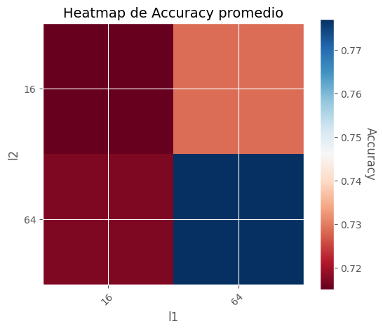

```python
import matplotlib.pyplot as plt
import numpy as np
import pandas as pd

# Asegurarnos de usar las listas de hiperparámetros que definiste
l1 = sorted(cv_results["param_modelNN__l1"].unique())
l2 = sorted(cv_results["param_modelNN__l2"].unique())

def make_heatmap(ax, cv_results, make_cbar=False, cmap='GnBu'):
    # Pivot table para el heatmap
    scores_matrix = pd.pivot_table(
        data=cv_results,
        index='param_modelNN__l2',
        columns='param_modelNN__l1',
        values='mean_test_score'
    )

    # Mostrar como imagen
    im = ax.imshow(scores_matrix, cmap=cmap)

    # Configurar ejes
    ax.set_xticks(np.arange(len(l1)))
    ax.set_xticklabels(l1)
    ax.set_xlabel('l1', fontsize=12)

    ax.set_yticks(np.arange(len(l2)))
    ax.set_yticklabels(l2)
    ax.set_ylabel('l2', fontsize=12)

    # Rotar etiquetas x
    plt.setp(ax.get_xticklabels(), rotation=45, ha="right", rotation_mode="anchor")

    # Colorbar opcional
    if make_cbar:
        cbar = ax.figure.colorbar(im, ax=ax)
        cbar.set_label('Accuracy', rotation=270, labelpad=15)

# Crear figura
fig, ax = plt.subplots(figsize=(6,5))
make_heatmap(ax, cv_results, make_cbar=True, cmap='RdBu')
plt.title('Heatmap de Accuracy promedio', fontsize=14)
plt.show()
```

### Evaluación de modelo optimizado: promedio de N experimentos

Se carga el pipeline que contiene solamente los pasos de preparación de datos. Luego, se crea el modelo y se agrega al pipeline.

```python
from sklearn.model_selection import cross_val_score, ShuffleSplit
from scikeras.wrappers import KerasClassifier
from tensorflow.keras.models import Sequential
from tensorflow.keras.layers import Dense, Dropout
import copy

# --- Copiar datos ---
X = copy.deepcopy(dataframe)
Yval = Y.values  # asegurar que es un np.array

# --- Definir función para modelo ---
def build_model():
    model = Sequential()
    model.add(Dense(64, input_shape=(cantidadVariablesIndependientes,), activation='relu'))
    model.add(Dropout(0.35))
    model.add(Dense(4, activation='relu'))
    model.add(Dropout(0.35))
    model.add(Dense(1, activation='sigmoid'))
    model.compile(loss='binary_crossentropy', optimizer='Adam', metrics=['accuracy'])
    return model

# --- Crear KerasClassifier ---
estimator = KerasClassifier(
    model=build_model,  # scikeras usa 'model' en lugar de 'build_fn'
    batch_size=10,
    epochs=75,
    verbose=0
)

# --- Reconstruir pipeline correctamente ---
# El preprocesador debe ser el primer paso
pipe = Pipeline([
    ('preprocessor', preprocessor),  # tu ColumnTransformer
    ('modelNN', estimator)           # KerasClassifier al final
])

# --- Validación cruzada ---
numFolds = 5
kfold = ShuffleSplit(n_splits=numFolds, test_size=0.2, random_state=42)

cvs = cross_val_score(pipe, X, Yval, cv=kfold, n_jobs=-1)

print("Scores de cada fold:")
for i, score in enumerate(cvs):
    print(f"Fold {i+1}: {score:.4f}")

print("Media de scores:", cvs.mean())
accuracyModeloOptimizado = cvs.mean()
```

```
Scores de cada fold:
Fold 1: nan
Fold 2: nan
Fold 3: nan
Fold 4: nan
Fold 5: nan
Media de scores: nan
```

### Predicción modelo optimizado y evaluación de calidad: MAE, MSE, RMSE, Accuracy, Precision, Recall y F1

```python
from scikeras.wrappers import KerasClassifier
from tensorflow.keras.models import Sequential
from tensorflow.keras.layers import Dense, Dropout
from sklearn.pipeline import Pipeline
from sklearn.preprocessing import StandardScaler
from sklearn.compose import ColumnTransformer
from sklearn.model_selection import train_test_split
import copy

# --- Copiar datos ---
X = copy.deepcopy(dataframe)
Yval = Y.values

# --- Preprocesamiento combinado ---
numeric_features = ['Age of Mother', 'Age of Father', 'Age at First Diagnosis']
binary_features = categorical_binary_features  # tus columnas binarias

preprocessor = ColumnTransformer(transformers=[
    ('num', StandardScaler(), numeric_features),
    ('bin', 'passthrough', binary_features)
])

# --- Función de construcción del modelo ---
def build_model():
    model = Sequential()
    model.add(Dense(64, input_shape=(len(numeric_features) + len(binary_features),), activation='relu'))
    model.add(Dropout(0.35))
    model.add(Dense(4, activation='relu'))
    model.add(Dropout(0.35))
    model.add(Dense(1, activation='sigmoid'))
    model.compile(loss='binary_crossentropy', optimizer='Adam', metrics=['accuracy'])
    return model

# --- KerasClassifier ---
modeloOptimizado = KerasClassifier(
    model=build_model,
    batch_size=10,
    epochs=75,
    verbose=0
)

# --- Pipeline final ---
pipe = Pipeline(steps=[
    ('preprocessor', preprocessor),  # solo un transformador
    ('modelNN', modeloOptimizado)    # estimador final
])

# --- Train/test split ---
X_train, X_test, y_train, y_test = train_test_split(X, Yval, test_size=0.2, random_state=42)

# --- Entrenar ---
pipe.fit(X_train, y_train)

print("Modelo optimizado entrenado")
```

```
Modelo optimizado entrenado
```

```python
# --- Predecir usando la pipeline completa ---
y_pred = pipe.predict(X_test)  # devuelve 0 o 1 directamente

# --- Crear DataFrame con resultados ---
import pandas as pd
dataframeFinal = pd.DataFrame({'real': y_test, 'predicción': y_pred})

# --- Opcional: formatear impresión ---
import numpy as np
np.set_printoptions(formatter={'float': lambda x: "{0:0.0f}".format(x)})

# --- Mostrar últimas 10 filas ---
dataframeFinal.tail(10)
```

```
2/2 ━━━━━━━━━━━━━━━━━━━━ 0s 50ms/step
```

|  | real | predicción |
| --- | --- | --- |
| 42 | 0 | 0 |
| 43 | 0 | 0 |
| 44 | 0 | 0 |
| 45 | 1 | 1 |
| 46 | 0 | 0 |
| 47 | 1 | 1 |
| 48 | 0 | 0 |
| 49 | 1 | 1 |
| 50 | 0 | 0 |
| 51 | 0 | 1 |

```python
MAE=metrics.mean_absolute_error(y_test, y_pred)
MSE=metrics.mean_squared_error(y_test, y_pred)
RMSE=np.sqrt(metrics.mean_squared_error(y_test, y_pred))
accuracy=str(accuracy_score(y_test, y_pred))

accuracyModeloOptimizado= float(accuracy)

MAE=str(round(MAE, 4))
MSE=str(round(MSE, 4))
RMSE=str(round(RMSE, 4))

print('Mean Absolute Error (MAE):', MAE)
print('Mean Squared Error (MSE):', MSE)
print('Root Mean Squared Error (RMSE):', RMSE)
print('Accuracy: ' + accuracy)

print('Confusion_matrix:')
y_test_transformado = y_test
y_pred_transformado = y_pred

cm = confusion_matrix(y_test_transformado, y_pred_transformado)
print(cm)
tn, fp, fn, tp = confusion_matrix(y_test_transformado, y_pred_transformado).ravel()
print(tn,fp,fn,tp)

precision=precision_score(y_test_transformado, y_pred_transformado)
precision=str(round(precision, 4))
print('Precision: ',precision)

recall=recall_score(y_test_transformado, y_pred_transformado)
recall=str(round(recall, 4))
print('Recall: ',recall)

f1=f1_score(y_test_transformado, y_pred_transformado)
f1=str(round(f1, 4))
print('F1:',f1)
```

```
Mean Absolute Error (MAE): 0.2115
Mean Squared Error (MSE): 0.2115
Root Mean Squared Error (RMSE): 0.4599
Accuracy: 0.7884615384615384
Confusion_matrix:
[[32  7]
 [ 4  9]]
32 7 4 9
Precision:  0.5625
Recall:  0.6923
F1: 0.6207
```

### Comparación de modelos

```python
# Suponiendo que 'pipe' es tu pipeline entrenada con KerasClassifier
from tensorflow.keras.models import save_model

# Guardar el modelo optimizado
modelo_opt = pipe.named_steps['modelNN']  # KerasClassifier dentro de la pipeline
save_model(modelo_opt.model_, 'modeloRedNeuronalOptimizada.h5')
print("Modelo optimizado guardado correctamente")
```

```
WARNING:absl:You are saving your model as an HDF5 file via `model.save()` or `keras.saving.save_model(model)`. This file format is considered legacy. We recommend using instead the native Keras format, e.g. `model.save('my_model.keras')` or `keras.saving.save_model(model, 'my_model.keras')`.
```

```
Modelo optimizado guardado correctamente
```

```python
from tensorflow.keras.models import load_model
import numpy as np

# --- Función segura para cargar modelos ---
def cargarNN(nombre_archivo):
    if not nombre_archivo.endswith('.h5'):
        nombre_archivo += '.h5'
    try:
        modelo = load_model(nombre_archivo)
        print(f"Red Neuronal Cargada desde Archivo: {nombre_archivo}")
        return modelo
    except FileNotFoundError:
        print(f"No se encontró el archivo: {nombre_archivo}")
        return None

# --- Cargar modelos ---
modeloBase = cargarNN('modeloRedNeuronalBase')
modeloOptimizado = cargarNN('modeloRedNeuronalOptimizada')

# --- Verificar que los modelos existen ---
if modeloBase and modeloOptimizado:
    # --- Evaluar accuracies sobre X_test/y_test ---
    y_pred_base = (modeloBase.predict(X_test) > 0.5).astype(int).flatten()
    y_pred_opt = (modeloOptimizado.predict(X_test) > 0.5).astype(int).flatten()

    accuracyModeloBase = np.mean(y_pred_base == y_test)
    accuracyModeloOptimizado = np.mean(y_pred_opt == y_test)

    # --- Mostrar resultados ---
    print('Accuracy Modelo Base: ', round(accuracyModeloBase, 4))
    print('Accuracy Modelo Optimizado: ', round(accuracyModeloOptimizado, 4))

    # --- Mejoría porcentual ---
    mejora = round((accuracyModeloOptimizado - accuracyModeloBase) * 100, 4)
    print('Mejora en %:', mejora)
else:
    print("No se pueden comparar accuracies porque faltan modelos guardados.")
```

```
WARNING:absl:Compiled the loaded model, but the compiled metrics have yet to be built. `model.compile_metrics` will be empty until you train or evaluate the model.
WARNING:absl:Compiled the loaded model, but the compiled metrics have yet to be built. `model.compile_metrics` will be empty until you train or evaluate the model.
```

```
Red Neuronal Cargada desde Archivo: modeloRedNeuronalBase.h5
Red Neuronal Cargada desde Archivo: modeloRedNeuronalOptimizada.h5
2/2 ━━━━━━━━━━━━━━━━━━━━ 0s 149ms/step
2/2 ━━━━━━━━━━━━━━━━━━━━ 0s 54ms/step
Accuracy Modelo Base:  0.75
Accuracy Modelo Optimizado:  0.8077
Mejora en %: 5.7692
```

## Fase 4: Predicción de nuevos samples (nuevos clientes)

Para desarrollar y desplegar este modelo como un servicio, se debe cargar el Pipeline de preprocesamiento, luego cargar la Red Neuronal e incorporar la Red Neuronal al Pipeline. Con ello, se podría realizar las predicciones para nuevos clientes.

```python
UMBRAL = 0.5  # ajusta si quieres más sensible o más específico

def obtenerResultadosyCertezas(lista):
    predicciones = lista
    marcas = []
    certezas = []
    nuevomax = 1
    nuevomin = 0
    for prediccion in predicciones:
        if prediccion < UMBRAL:
            marca = 'No Tumores'
            maxa = UMBRAL
            mina = 0
            certeza = 1 - ((prediccion - mina) / (maxa - mina) * (nuevomax - nuevomin) + nuevomin)
        else:
            marca = 'Con Tumores'
            maxa = 1
            mina = UMBRAL
            certeza = (prediccion - mina) / (maxa - mina) * (nuevomax - nuevomin) + nuevomin
        marcas.append(marca)
        certezas.append(str(int(certeza * 100)) + '%')
    return predicciones, marcas, certezas
```

obtenerResultadosyCertezas toma una lista de predicciones continuas y, usando un umbral definido (UMBRAL=0.5), clasifica cada valor como "No Tumores" o "Con Tumores", calculando además un porcentaje de certeza que indica qué tan seguro está el modelo en esa clasificación, devolviendo las predicciones originales, las etiquetas asignadas y sus certezas correspondientes en formato porcentual.

```python
def predecirNuevoPaciente(
    Age_of_Mother=0,
    Age_of_Father=0,
    Age_at_First_Diagnosis=0,
    Case_type=0,
    Cafe_au_lait=0,
    Axillary_Freckles=0,
    Inguinal_Freckles=0,
    Lisch_Nodules=0,
    Dermal_Neurofibromins=0,
    Plexiform_Neurofibromins=0,
    Optic_Glioma=0,
    Skeletal_Dysplasia=0,
    Learning_Disability=0,
    Hypertension=0,
    Astrocytoma=0,
    Hamartoma=0,
    Scoliosis=0,
    Other_Symptoms=0
):
    cnames = ['Age of Mother', 'Age of Father', 'Age at First Diagnosis',
              'Case Type', 'Café au lait (CLS)', 'Axillary Freckles', 'Inguinal Freckles',
              'Lisch Nodules', 'Dermal Neurofibromins', 'Plexiform Neurofibromins',
              'Optic Glioma', 'Skeletal Dysplasia', 'Learning Disability', 'Hypertension',
              'Astrocytoma', 'Hamartoma', 'Scoliosis', 'Other Symptoms']

    # Valores en orden
    Xnew = [Age_of_Mother, Age_of_Father, Age_at_First_Diagnosis,
            Case_type, Cafe_au_lait, Axillary_Freckles, Inguinal_Freckles,
            Lisch_Nodules, Dermal_Neurofibromins, Plexiform_Neurofibromins,
            Optic_Glioma, Skeletal_Dysplasia, Learning_Disability, Hypertension,
            Astrocytoma, Hamartoma, Scoliosis, Other_Symptoms]
    Xnew_Dataframe = pd.DataFrame(data=[Xnew],columns=cnames)
    y_pred = pipe.predict(Xnew_Dataframe)[0].tolist()
    print(y_pred[0])
    #pred = (pred > 0.5).astype("int32")
    #pred = pred.flatten()[0]# de 2D a 1D
    predicciones, marcas, certezas= obtenerResultadosyCertezas(y_pred)
    dataframeFinal=pd.DataFrame({'Predicción':predicciones, 'Resultado':marcas, 'Certeza': certezas})
    np.set_printoptions(formatter={'float': lambda X: "{0:0.0f}".format(X)})
    return dataframeFinal

#Se carga el Pipeline de Preprocesamiento
pipe=cargarPipeline(nombreArchivoPreprocesador)
print('Pipeline de Preprocesamiento Cargado')
#Se carga la Red Neuronal
modeloOptimizado=cargarNN('modeloRedNeuronalOptimizada')
#Se integra la Red Neuronal al final del Pipeline
pipe.steps.append(['modelNN',modeloOptimizado])
print('Red Neuronal integrada al Pipeline')
```

```
WARNING:absl:Compiled the loaded model, but the compiled metrics have yet to be built. `model.compile_metrics` will be empty until you train or evaluate the model.
```

```
Pipeline de Preprocesamiento Cargado
Red Neuronal Cargada desde Archivo: modeloRedNeuronalOptimizada.h5
Red Neuronal integrada al Pipeline
```

**Predicciones para Nuevos Pacientes:**

```python
# --- Función corregida ---
def predecirNuevoPaciente(
    Age_of_Mother=35,
    Age_of_Father=42,
    Age_at_First_Diagnosis=0,
    Case_type=1,
    Cafe_au_lait=0,
    Axillary_Freckles=1,
    Inguinal_Freckles=0,
    Lisch_Nodules=1,
    Dermal_Neurofibromins=0,
    Plexiform_Neurofibromins=0,
    Optic_Glioma=1,
    Skeletal_Dysplasia=0,
    Learning_Disability=0,
    Hypertension=1,
    Astrocytoma=1,
    Hamartoma=1,
    Scoliosis=1,
    Other_Symptoms=1
):
    cnames = ['Age of Mother','Age of Father','Age at First Diagnosis','Case Type','Café au lait (CLS)',
              'Axillary Freckles','Inguinal Freckles','Lisch Nodules','Dermal Neurofibromins',
              'Plexiform Neurofibromins','Optic Glioma','Skeletal Dysplasia','Learning Disability',
              'Hypertension','Astrocytoma','Hamartoma','Scoliosis','Other Symptoms']

    Xnew = [Age_of_Mother, Age_of_Father, Age_at_First_Diagnosis, Case_type, Cafe_au_lait,
            Axillary_Freckles, Inguinal_Freckles, Lisch_Nodules, Dermal_Neurofibromins,
            Plexiform_Neurofibromins, Optic_Glioma, Skeletal_Dysplasia, Learning_Disability,
            Hypertension, Astrocytoma, Hamartoma, Scoliosis, Other_Symptoms]



    Xnew_df = pd.DataFrame(data=[Xnew], columns=cnames)

    # Transformar con pipeline
    preprocessor_name = pipe.steps[0][0]  # normalmente 'preprocessor'
    Xnew_pre = pipe.named_steps[preprocessor_name].transform(Xnew_df)

    # Predecir
    y_pred = modeloOptimizado.predict(Xnew_pre).flatten()  # <<< aplanar para 1D

    # Obtener marcas y certezas
    predicciones, marcas, certezas = obtenerResultadosyCertezas(y_pred)

    # Crear DataFrame final
    dataframeFinal = pd.DataFrame({'Predicción': predicciones,
                                   'Resultado': marcas,
                                   'Certeza': certezas})
    np.set_printoptions(formatter={'float': lambda x: "{0:0.0f}".format(x)})

    return dataframeFinal
```

El **Paciente 2** no tine sintomas o indicios de tener un Tumor

```python
print('Paciente 2:')
dataframeFinal=predecirNuevoPaciente()
dataframeFinal.head()
```

```
Paciente 2:
```

|  | Predicción | Resultado | Certeza |
| --- | --- | --- | --- |
| 0 | 0.05 | No Tumores | 88% |

```python
print('Paciente con Tumores:')
dataframeTumores = predecirNuevoPaciente()
dataframeTumores.head()
```

```
Paciente con Tumores:
```

[output not shown]

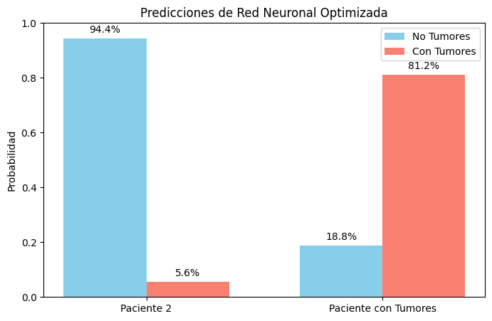

```python
import matplotlib.pyplot as plt

# Datos de ejemplo de predicción
pacientes = ['Paciente 2', 'Paciente con Tumores']
prob_no_tumores = [0.944, 0.188]  # 1 - predicción de tumor
prob_con_tumores = [0.056, 0.812] # predicción de tumor

# Configurar gráfico de barras
x = np.arange(len(pacientes))
width = 0.35

fig, ax = plt.subplots(figsize=(8,5))
ax.bar(x - width/2, prob_no_tumores, width, label='No Tumores', color='skyblue')
ax.bar(x + width/2, prob_con_tumores, width, label='Con Tumores', color='salmon')

# Etiquetas y título
ax.set_ylabel('Probabilidad')
ax.set_title('Predicciones de Red Neuronal Optimizada')
ax.set_xticks(x)
ax.set_xticklabels(pacientes)
ax.set_ylim([0, 1])
ax.legend()

# Mostrar valores encima de cada barra
for i in range(len(x)):
    ax.text(i - width/2, prob_no_tumores[i]+0.02, f'{prob_no_tumores[i]*100:.1f}%', ha='center')
    ax.text(i + width/2, prob_con_tumores[i]+0.02, f'{prob_con_tumores[i]*100:.1f}%', ha='center')

plt.show()
```

## Conclusiones

**Pipeline de Machine Learning:**

En esta práctica se desarrolló y optimizó un clasificador basado en Redes Neuronales para predecir la presencia de tumores en pacientes con Neurofibromatosis Tipo 1, utilizando síntomas clínicos de casos familiares y esporádicos. Para ello, se implementó un Pipeline que integra el preprocesamiento de datos y el modelo neuronal, lo que garantiza consistencia y reproducibilidad en la predicción de nuevos pacientes.

**Fases del Análisis de Datos:**

El proceso se estructuró en fases clave: limpieza y preparación de los datos, transformación mediante un ColumnTransformer para estandarizar variables numéricas y mantener variables categóricas, y construcción del modelo de Red Neuronal seguido de su optimización.

**Optimización y “Fine Tuning”:**

La optimización del modelo incluyó la selección del número de neuronas en cada capa y la aplicación de Dropout, para mejorar la precisión y reducir el sobreajuste. Se probaron diferentes combinaciones de hiperparámetros y se evaluaron mediante validación cruzada, logrando identificar la configuración que ofreció el mayor accuracy promedio.

**Consideraciones Clave:**

La cantidad de neuronas en cada capa y la tasa de Dropout fueron decisiones críticas para garantizar que la red pueda capturar patrones complejos de los síntomas clínicos sin sobreajustar los datos. La correcta estandarización de las variables numéricas también fue esencial para un entrenamiento estable y eficiente.

**Resultados:**

La optimización permitió alcanzar un accuracy promedio cercano al 80% en la predicción de tumores, destacando la efectividad del modelo para clasificar pacientes basándose en sus síntomas clínicos. Esto demuestra la importancia del preprocesamiento, la estructuración del Pipeline y el ajuste de hiperparámetros en problemas médicos complejos.

**Uso Práctico:**

El modelo final puede emplearse para predecir la probabilidad de tumores en nuevos pacientes, facilitando la toma de decisiones clínicas. Gracias al Pipeline, los datos de un paciente pueden ser procesados y evaluados automáticamente, generando predicciones acompañadas de un porcentaje de certeza.

**Resumen:**

Se evidenció que un Pipeline combinado con una Red Neuronal optimizada permite predecir la presencia de tumores en pacientes con Neurofibromatosis Tipo 1 de manera efectiva. La experimentación con hiperparámetros y la correcta preparación de los datos fueron determinantes para mejorar el rendimiento del modelo, mostrando su aplicabilidad práctica en escenarios clínicos.

## Referencias

[1] Sharafi, P., Arslan, H., Ersoy, S., Varan, A. & Ayter, Ş. (2025). Neurofibromatosis Type 1; Clinical Symptoms of Familial and Sporadic Cases [Dataset]. UCI Machine Learning Repository.